```python
from IPython.display import HTML
HTML('''<script>
code_show=true;
function code_toggle() {
 if (code_show){
 $('div.input').hide();
 } else {
 $('div.input').show();
 }
 code_show = !code_show
}
$( document ).ready(code_toggle);
</script>
The raw code for this IPython notebook is by default hidden for easier reading.
To toggle on/off the raw code, click <a href="javascript:code_toggle()">here</a>.''')
```

The raw code for this IPython notebook is by default hidden for easier reading. To toggle on/off the raw code, click here.

```python
from IPython.core.display import HTML
HTML("""
<style>

div.cell { /* Tunes the space between cells */
margin-top:1em;
margin-bottom:1em;
}

div.text_cell_render h1 { /* Main titles bigger, centered */
font-size: 2.2em;
line-height:1.4em;
text-align:center;
}

div.text_cell_render h2 { /*  Parts names nearer from text */
margin-bottom: -0.4em;
}


div.text_cell_render { /* Customize text cells */
font-family: 'Times New Roman';
font-size:1.5em;
line-height:1.4em;
padding-left:3em;
padding-right:3em;
}
</style>
""")
```

# Cycle Crunch - Online used/new motorcycles ads

```python
from IPython.display import HTML
HTML('<iframe src = https://www.cyclecrunch.com/Search/All_Makes/All_Models/Motorcycles width = 1200 height = 1080></iframe>')
```

[interactive chart not shown]

```python
from IPython.display import HTML
HTML('<iframe src = https://www.cyclecrunch.com/ForSale/Harley-Davidson/Sportster_Roadster/558332 width = 1200 height = 1080></iframe>')
```

[interactive chart not shown]

```python
import time
start_time = time.time()
import math
import re
from bs4 import BeautifulSoup
import requests
import unicodedata
import numpy as np
import pandas as pd

# Convert unicode to string
def conv_var(var):
    if type(var) == unicode:
            var = unicodedata.normalize('NFKD', var).encode('ascii','ignore')
    return var

# Initialization of the website search path
site_path = "https://www.cyclecrunch.com"
search_path = "/Search/All_Makes/All_Models/Motorcycles"
page = 1
nbpage = 2501

# initialization of the variables
yr, pr, Id, name, loc, col, listed, model, description = [], [], [], [], [], [], [], [], []
condit, mile, loc, ttl, city, state, make, pr2 = [], [], [], [], [], [], [], []
# initialization dictionary
dic = {"year" : [], "price" : [], "make" : [], "name" : [], "color" : [], "condition" : [],
       "km" : [], "city" : [], "state" : [], "Id" : [], "model" : [], "listed" : [],
        "price2" : [], "description" : []}


current_path = search_path


### while loop to sift through the pages
# sift through the first pages of the website
while page < nbpage:
    # output for the first page
    outpg = BeautifulSoup(requests.get(site_path + current_path).text)

    res = ["bike bikeresult-grid feat", "bike bikeresult-grid feat hglt"]
    # details contained in the current page

    opg2 = outpg.find("div", class_ = "search-result-wrapper")

    opg = []
    opg.append(opg2.find("div"))
    while opg[-1].find_next_sibling("div") != None:
        opg.append(opg[-1].find_next_sibling("div"))

    for x in opg:

        tempyr = x.get("data-year")
        if tempyr != None: yr.append(tempyr)
        else: yr.append("NaN")

        temppr = x.get("data-price")
        if temppr != None: pr.append(temppr)
        else: pr.append("NaN")

        tempId = x.get("data-year")
        if tempId != None: Id.append(tempId)
        else: Id.append("NaN")

        tempname = x.div.find("div", {"itemprop" : "name"}).string
        if tempname != None:
            name.append(conv_var(re.sub('\xae', '', tempname)))
        else:
            name.append("NaN")

        temploc = str(x.div.find("div", {"class" : "location"}).string)
        if temploc != None:
            loc.append(temploc)
        else:
            loc.append("NaN")

        tempttl = conv_var(x.div.find("div", {"class" : "ttl"}).get("title"))
        if tempttl != None:
            ttl.append(tempttl)
        else:
            ttl.append("NaN")

    ip = outpg.find_all("div", {"class" : "search-result-wrapper"})
    url_current = ["" for x in range(0, len(ip[0].contents))]
    for i in range(0, len(url_current)):
        tt = ip[0].contents[i].a.get("href")
        if type(tt) == unicode:
            tt = unicodedata.normalize('NFKD', tt).encode('ascii','ignore')
            url_current[i] = site_path + tt
        else:
            url_current[i] = site_path + tt

    # inner page results
    for url in url_current:
        inpage = BeautifulSoup(requests.get(url).text)
        wd = inpage.find("section", class_ = "widget detail")
        bw = inpage.find("div", class_ = "bike-wrapper")
        ta = inpage.find("article", class_ = "text-area")

        if wd != None:

            temppr2 = wd.find("dt", text = "Price:")
            if temppr2 != None:
                pr2.append(temppr)
            else:
                pr2.append("NaN")

            tempcol = wd.find("dt", text = "Color:")
            if tempcol != None:
                tempcol = tempcol.find_next_sibling("dd")
                if tempcol.string:
                    col.append(conv_var(tempcol.string.replace("/", '.')))
                else:
                    col.append("NaN")
            else:
                col.append("NaN")

            tempcondit = wd.find("dt", text = "Condition:")
            if tempcondit != None:
                tempcondit = tempcondit.find_next_sibling("dd")
                if tempcondit != None:
                    condit.append(str(tempcondit.string))
                else:
                    condit.append("NaN")
            else:
                condit.append("NaN")

            tempmile = wd.find("dt", text = "Mileage:")
            if tempmile != None:
                tempmile = tempmile.find_next_sibling("dd")
                if tempmile != None:
                    mile.append(str(tempmile.string))
                else:
                    mile.append("NaN")
            else:
                mile.append("NaN")

            tempcity = wd.find("dt", text = "Location:")
            if tempcity != None:
                tempcity = tempcity.find_next_sibling("dd")
                if tempcity != None:
                    city.append(str(tempcity.string.split(",")[0]))
                else:
                    city.append("NaN")
            else:
                city.append("NaN")

            tempstate = wd.find("dt", text = "Location:")
            if tempstate != None:
                tempstate = tempstate.find_next_sibling("dd")
                if tempstate != None:
                    state.append(str(tempstate.string.split(",")[1]))
                else:
                    state.append("NaN")
            else:
                state.append("NaN")

            templisted = wd.find("dt", text = "Listed: ")
            if templisted != None:
                templisted = templisted.find_next_sibling("dd")
                if templisted.string:
                    listed.append(conv_var(templisted.string.replace("/", '.')))
                else:
                    listed.append("NaN")
            else:
                listed.append("NaN")

        else:
            col.append("NaN")
            condit.append("NaN")
            mile.append("NaN")
            city.append("NaN")
            state.append("NaN")
            listed.append("NaN")


        if bw != None:

            if bw.get("data-make") != None:
                make.append(conv_var(bw.get("data-make")))
            else:
                make.append("NaN")
        else: make.append("NaN")



        if ta != None:

            if ta.p != None:
                if ta.p.string:
                    description.append(conv_var(ta.p.string.replace("/", '.')))
                else:
                    description.append("NaN")
            else:
                description.append("NaN")
        else: description.append("NaN")



        km = ["" for x in range(0, len(mile))]

        for i in range(0, len(mile)):
            for st in mile[i].split(","):
                km[i] = str(km[i])
                km[i] += st
                if math.isnan(float(km[i])) == False:
                    km[i] = int(float(km[i])*1.60934)
                else:
                    km[i] = np.nan

        model.append(url.split("/")[-2])

    dic["year"] = yr
    dic["price"] = pr
    dic["price2"] = pr2
    dic["make"] = make
    dic["name"] = name
    dic["color"] = col
    dic["condition"] = condit
    dic["km"] = km
    dic["city"] = city
    dic["state"] = state
    dic["Id"] = Id
    dic["listed"] = listed
    dic["model"] = model
    dic["description"] = description


    #url for the next page
    next_page = outpg.find_all("span", {"class" : "pgs"})[0].contents[6].get("href")

    current_path = next_page
    print page
    page += 1

#bike = pd.DataFrame(dic)
#bike.to_csv('bike400.csv')

print("--- %s seconds ---" % (time.time() - start_time))
```

Initial goal in scraping the data:

- get a view on the US market:
  - proportion of motorcycles by brand
  - compare it to other markets
- identify characteristics by brands or models through several variables:
  - price vs year by top brand: how fast do models depreciate
  - distance traveled per brand and difference in habits (working, retired?)
- use additional rainfall information to make classification easier

```python
import numpy as np
import pandas as pd
import warnings
warnings.filterwarnings('ignore')

%matplotlib inline
import matplotlib.pyplot as plt
import seaborn as sns
%matplotlib inline
plt.style.use('ggplot')

bike = pd.read_csv('bike12812.csv')
```

## The data

This dataframe was obtained by scraping the first 1,282 pages of Cycle-Crunch.com

```python
bike = bike.drop(['Unnamed: 0', 'Id', 'description', 'name'], axis = 1, inplace = False)
bike.head(5)
```

|  | city | color | condition | km | listed | make | model | price | state | year |
| --- | --- | --- | --- | --- | --- | --- | --- | --- | --- | --- |
| 0 | cass lake | custom | Used | 30577 | 6.28.2015 | Harley-Davidson | Sportster_Roadster | 3500 | MN | 1981 |
| 1 | Newtown Square | black | Used | 49567 | 7.19.2014 | Harley-Davidson | Sportster_883 | 3500 | PA | 1989 |
| 2 | Mico | Black | Used | 27358 | 9.15.2015 | Harley-Davidson | Sportster_883 | 3850 | TX | 1994 |
| 3 | Dudley | Kandy Apple Red With Gold Flames | Used | 22530 | 7.21.2015 | Harley-Davidson | Sportster_883 | 3995 | MA | 1993 |
| 4 | Charlotte | Yellow | Used | 25749 | 11.18.2015 | Harley-Davidson | Sportster1200_Anniversary | 4000 | NC | 2003 |

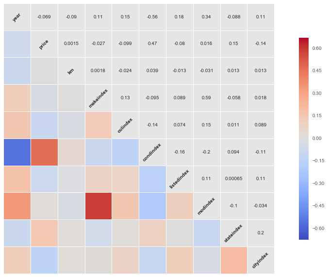

```python
bike2 = bike
group = ['make', 'color', 'condition', 'listed', 'model', 'state', 'city']
ind_name = ['makeindex', 'colindex', 'condindex', 'listedindex', 'modindex', 'stateindex', \
            'cityindex']
size_name = ['makesize', 'colsize', 'condsize', 'listedsize', 'modsize', 'statesize', \
             'citysize']

for g, ind, sz in zip(group, ind_name, size_name):
    biketemp = bike.groupby(g)[g].agg(['size']).sort('size')
    biketemp[ind] = np.arange(len(biketemp))
    biketemp[g] = biketemp.index
    biketemp = biketemp.rename(columns = {"size" : sz})
    bike2 = pd.merge(bike2, biketemp, how = 'left', on = g)

plt.rcParams['figure.figsize'] = 18, 10
sns.corrplot(bike2[['year', 'price', 'km'] + ind_name]);
```

Most variables seem poorly corrolated to one another. But some obvious dependencies are still highlighted: condition(used or new)/price, brand/model.

Some less obvious correlations are also there: year, color and listed date/city.

## Overview

The listed ads are flooded with Harley-Davidsons...

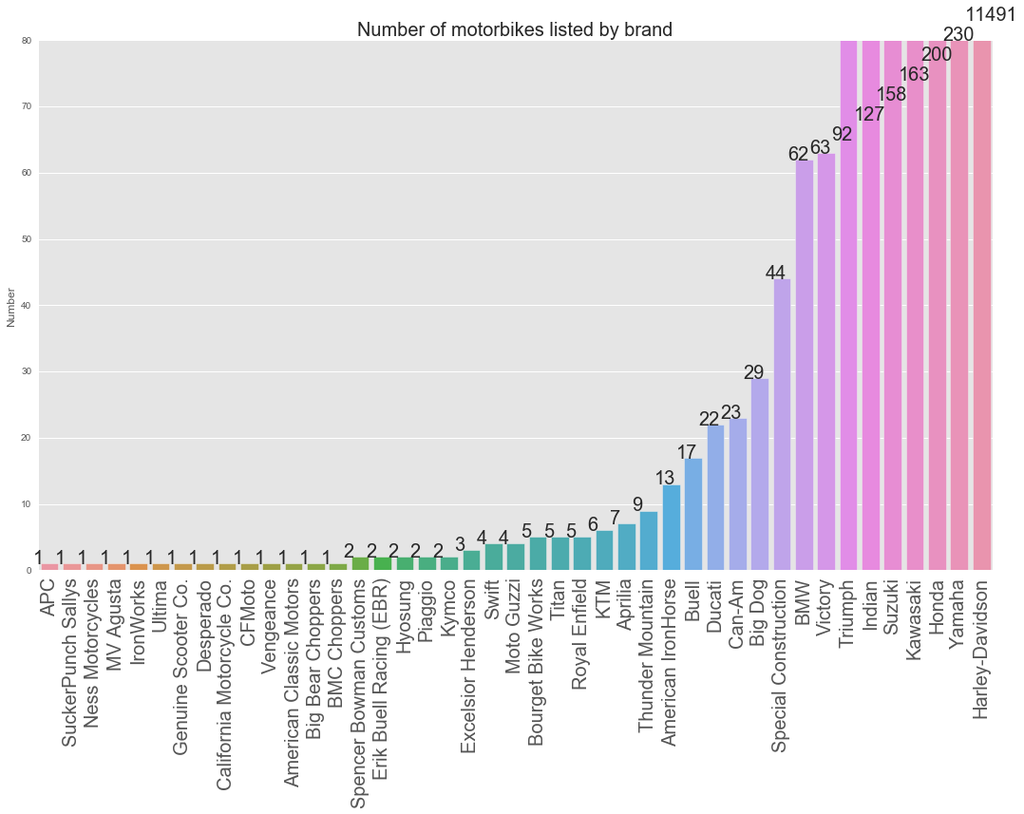

```python
import random
makelist = np.unique(bike.make);
bikemake = bike.groupby('make')['make'].agg(['size']).sort('size');
limval = 80

n = len(bikemake)
p = (65 - limval)/(38 - n)

xval = np.arange(n) - 0.75

yval = []
for t in bikemake['size'][0:-7]:
    yval.append(t)
temp = 62 + p*np.arange(1,8)
for t in temp:
    yval.append(t)

plt.rcParams['figure.figsize'] = 18, 10
sns.barplot(np.arange(len(bikemake)), bikemake['size']);
sns.plt.ylim(0, limval);
for i in range(n):
    plt.text(xval[i], yval[i], bikemake['size'][i], size = 20);
plt.xticks(np.arange(n) - 1/(n), bikemake.index, fontsize = 20, rotation = 90);
plt.title('Number of motorbikes listed by brand', size = 20)
plt.ylabel('Number')
plt.tick_params(axis = u'both', which = u'both',length = 0)
```

This seems a clear sign of the long time domination of Harley-davidson over the US market, as is confirmed by this 2012 report.

Here is a 2012 report of the market shares of the US market.

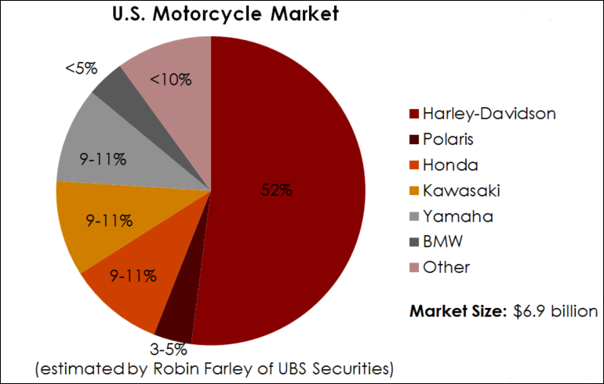

```python
from PIL import Image
img = Image.open('hd-share.png')
img
```

This comes in sheer contrast to European markets. Take for instance the French one:

```python
freMkt = pd.read_csv("FrenchMarketShare.csv")
freMkt.head(9)
```

|  | Rang | Marque | Moto 125 | Moto + 125 | 2015 | 2014 | evo 2014/2015 | PDM |
| --- | --- | --- | --- | --- | --- | --- | --- | --- |
| 0 | 1 | YAMAHA | 2573 | 13240 | 15813 | 15767 | 0,3% | 16,9% |
| 1 | 2 | BMW | NaN | NaN | 11329 | 10679 | 6,1% | 12,1% |
| 2 | 3 | HONDA | 2553 | 8684 | 11237 | 13691 | -17,9% | 12,0% |
| 3 | 4 | KAWASAKI | 40 | 11189 | 11229 | 11348 | -1,0% | 12,0% |
| 4 | 5 | HARLEY | NaN | NaN | 7538 | 8068 | -6,6% | 8,1% |
| 5 | 6 | SUZUKI | 531 | 6769 | 7300 | 7320 | -0,3% | 7,8% |
| 6 | 7 | KTM | 1519 | 4385 | 5904 | 6346 | -7,0% | 6,3% |
| 7 | 8 | TRIUMPH | NaN | NaN | 5093 | 5147 | -1,0% | 5,4% |
| 8 | 9 | DUCATI | NaN | NaN | 4391 | 3610 | 21,6% | 4,7% |

So the best selling American motorbike will look like...

```
                             size
model
Road_King                     367
Heritage_Softail_Classic      538
Street_Glide                  633
Electra_Glide_Ultra_Limited   635
Street_Glide_Special          673
```

[figure not shown]

```python
mostpopHD = bike.groupby('model')['model'].agg(['size']).sort('size')
print mostpopHD.tail()

from PIL import Image
img = Image.open('hd-street-glide-special.jpg')
img
```

... and the French one will look like

[figure not shown]

```python
from PIL import Image
img = Image.open('yam-mt09.jpg')
img
```

## Proportion of used/new motorbikes for sale in the data

Although Harley-Davidson has largely dominated the US market, they seem to have some issues renewing their image as their main target (45+ white male) grow thinner among the US demographics.

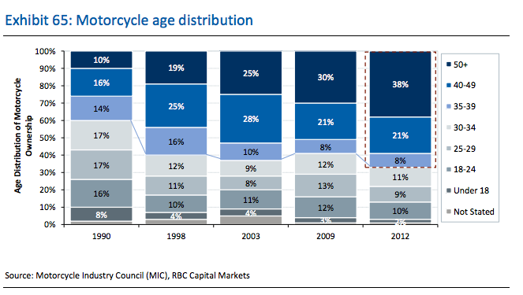

```python
from PIL import Image
import pylab
import matplotlib.cm as cm
import matplotlib as plt
import numpy as np

img = Image.open('US-owners-age.png')
#img2 = Image.open('HD-demographics.jpg')

img
```

However, we don't see any weakening from HD in the data at hand here. If anything, the trend seems to go in the opposite direction with more HD vehicles in recent years. Regardless of the condition (Used/New), the proportion of HD vehicles listed for sale appears steady.

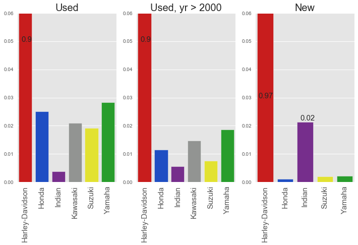

```python
bkmake = bike2[bike2.makesize > 100]
bkmakeL = bike2[(bike2.makesize > 100) & (bike2.year > 2010)]

makelist = np.unique(bkmake.make);
bkmakeNew = bkmake[bkmake.condition == 'New'].groupby('make').agg('size')
bkmakeUsed = bkmake[bkmake.condition == 'Used'].groupby('make').agg('size')
bkmakeUsedL = bkmakeL[bkmakeL.condition == 'Used'].groupby('make').agg('size')

propUsed = bkmakeUsed/len(bkmake[bkmake.condition == 'Used'])
propUsedL = bkmakeUsedL/len(bkmakeL[bkmakeL.condition == 'Used'])
propNew = bkmakeNew/len(bkmake[bkmake.condition == 'New'])

plt.rcParams['figure.figsize'] = 12, 6
##
plt.subplot(131);
color = ['red', 'blue', 'purple', 'grey', 'yellow', 'green']
sns.barplot(np.arange(len(bkmakeUsed)), propUsed, palette = sns.xkcd_palette(color));
plt.xticks(np.arange(len(bkmakeUsed)), bkmakeUsed.index, fontsize = 15, rotation = 90);
plt.tick_params(axis=u'both', which=u'both',length=0);
plt.title('Used', size = 20);
plt.ylim(0, 0.06);
plt.text(-0.25, 0.05, round(propUsed[0], 2), size = 15)
##
plt.subplot(132);
sns.barplot(np.arange(len(bkmakeUsedL)), propUsedL, palette = sns.xkcd_palette(color));
plt.xticks(np.arange(len(bkmakeUsedL)), bkmakeUsedL.index, fontsize = 15, rotation = 90);
plt.tick_params(axis=u'both', which=u'both',length=0);
plt.title('Used, yr > 2000', size = 20);
plt.ylim(0, 0.06);
plt.text(-0.25, 0.05, round(propUsed[0], 2), size = 15)
##
plt.subplot(133);
color2 = ['red', 'blue', 'purple', 'yellow', 'green']
sns.barplot(np.arange(len(bkmakeNew)), propNew, palette = sns.xkcd_palette(color2));
plt.title('New', size = 20);
xlst = [-0.35, 1.75]
ylst = [0.03, 0.022]
vallst = [round(propNew[0], 2), round(propNew[2], 2)]
for i, j, k in zip(xlst, ylst, vallst):
    plt.text(i, j, k, size = 15);
plt.ylim(0, 0.06);
plt.xticks(np.arange(len(bkmakeNew)), bkmakeNew.index, fontsize = 15, rotation = 90);
plt.tick_params(axis=u'both', which=u'both',length=0);
```

## Characteristics by brand

Although the vast majority of our data here consists of Harley-Davidsons, we try to find some characteristics for the different avalaible brands.

### Prices evolution

Though few data are available for year < 1980 (only 26 bikes listed), we see a funny bouncing showing how valuable these old-style models have become.

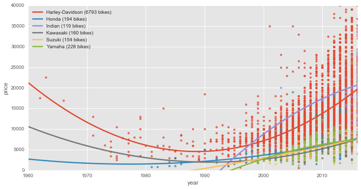

```python
bkmake = bike2[bike2['makesize'] > 100]
bkmake = bkmake[bkmake.price != 0]
mkleg = []
for mk in np.unique(bkmake.make):
    mkleg.append("%s (%s bikes)" %(mk, len(bkmake.make[bkmake.make == mk])))

for mk, df in bkmake.groupby('make'):
    sns.regplot(df.year, df.price, order = 2, ci = None)
    #plt.plot(df.year, df.price, '.')#, order = 2, ci = None)
    plt.ylim([0, 4e4])
    plt.xlim([1960, 2016])
    #plt.ylim([0, 4e4])
    #plt.xlim([1950, 2016])
plt.legend(mkleg, loc = 2)
plt.tick_params(axis=u'both', which=u'both',length=0);
```

The most ancient bike listed is a 1937 Velocette Mac 350 from York in Pennsylvania

[figure not shown]

```python
from PIL import Image
img = Image.open('velo-mac350.jpg')
img
```

Zooming in on recent years we can evaluate more clearly the depreciation

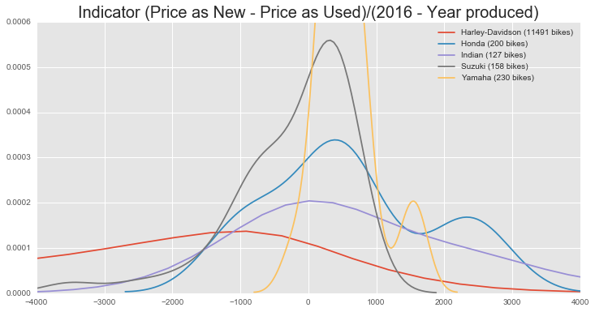

```python
def diffPr(A, B, C):
    temp = []
    for a, b, c in zip(A, B, C):
        if c != 2016: temp.append((a - b)/(2016 - c))
        else: temp.append(0)
    return temp

bkmake = bike2[(bike2.makesize > 100) & (bike2.year > 1995)]

avgPr = bkmake.groupby('model')['price'].agg('mean')
newPr = bkmake[bkmake.condition == 'New'].groupby('model')['price'].agg('mean')
newpr = pd.DataFrame({'model' : newPr.index, 'newpr' : [int(x) for x in newPr]})

bkmake2 = pd.merge(bkmake[bkmake.condition == 'Used'], newpr, how = 'right', on = 'model')
bkmake2['diffpr'] = diffPr(bkmake2.newpr, bkmake2.price, bkmake2.year)


plt.rcParams['figure.figsize'] = 12, 6
mkleg2 = []
for mk, df in bkmake2.groupby('make'):
    mkleg2.append("%s (%s bikes)" %(mk, \
                        int(np.unique(bkmake2[bkmake2.make == mk]['makesize'])[0])))
    sns.kdeplot(df.diffpr)
    plt.ylim([0, 6e-4])
    plt.xlim([-4e3, 4e3])
plt.legend(mkleg2)
plt.title('Indicator (Price as New - Price as Used)/(2016 - Year produced)', size = 20)
plt.tick_params(axis=u'both', which=u'both',length=0);
```

We see what is probably a big difference in HD users habits: the difference between the price of used models and their price as new tend to be negative, as most riders love to cutomize their motorbikes, often spending half the price as new in accessories/painting jobs/exhaust pipes etc..

## Yearly mileage

[figure not shown]

```python
bkmake = bike2[bike2['makesize'] > 100]

bkmake['ydist'] = bkmake.km/(2017 - bkmake.year)

mkleg = []
for mk, df in bkmake2.groupby('make'):
    mkleg.append("%s (%s bikes)" %(mk, \
                        int(np.unique(bkmake[bkmake.make == mk]['makesize'])[0])))
    sns.kdeplot(df['ydist'], shade = True)
    plt.xlim([-5e2, 8e3])
plt.legend(mkleg)
plt.title("Distribution of the yearly mileage per brands", size = 20)
plt.xlabel('ydist')
plt.tick_params(axis=u'both', which=u'both',length=0);
```

Surprisingly Harley-Davidson's yearly mileage peak is the lowest. This might be due to the fact they keep their bike longer than others (people tend to keep longer their motorbikes when customized). But the Harley's tail is pretty thick and probably accounts for occasional travelers.

Suzuki has the highest peak which might correspond to people using their motorbike to commute or for holiday road.trips.

## The rainfall indicator

We may assume that people who often drive in rainy regions are a particular type of consumers who will more likely buy a model that is adapted to everyday-driving or to long trips.

Can we find this in the data? We try to use: pkm = precipitation*yearly mileage

The assumption being that multiplying by the average precipitation per city should drift further away the peaks of owners with the highest mileage, thus easing the disctinction.

```python
from IPython.display import HTML
HTML('<iframe src = http://www.weatherbase.com width = 600 height = 800></iframe>')
```

[interactive chart not shown]

```python
from bs4 import BeautifulSoup
import requests
import mechanize
import cookielib
import pandas as pd
from sys import stdout
from time import sleep

# Browser
br = mechanize.Browser()

# Allow cookies
cj = cookielib.LWPCookieJar()
br.set_cookiejar(cj)

line = 0

precipitation = []
cty = []
precip = []
cty2 = []
abbr = []

err = []

bike = pd.read_csv("/Users/boulenge/Desktop/Projects/Project3 - WebSraping/bike8580.csv")

city_info = pd.DataFrame(index = bike.city, columns = \
                    ['cty', 'cty2', 'abb', 'precip', 'precipitation'])
city_info['cty2'] = city_info.index

for i in range(0, len(bike.city)):
    abb = ''.join(bike.iloc[i, 13].split())
    if abb in states.keys():
        city_info['abb'][i] = abb
    else:
        city_info['abb'][i] = "NaN"


for city in city_info.index:
    temp = [city, city_info[city_info.index == city]['abb'][0]]
    if temp[0] != "NaN" and temp[1] != "NaN" and temp[1] in states.keys():
        temp2 = " ".join(map(lambda x: x.capitalize(), temp[0].split(" "))) \
                         + ", " + states[temp[1]]
        # Browser options
        br.set_handle_equiv(True)
        br.set_handle_redirect(True)
        br.set_handle_referer(True)
        br.set_handle_robots(False)

        # Follows refresh 0 but not hangs on refresh > 0
        br.set_handle_refresh(mechanize._http.HTTPRefreshProcessor(), max_time=1)

        # Specify browser to emulate
        br.addheaders = [('User-agent',
                  'Mozilla/5.0 (X11; U; Linux i686; en-US; rv:1.9.0.1) Gecko/2008071615 Fedora/3.0.1-1.fc9 Firefox/3.0.1')]



        url = 'http://www.weatherbase.com/search/search.php3'
        br.open(url)
        response = br.response()

        br.select_form('searchform')

        form = str(city.upper())
        br.form['query'] = form
        req = br.submit()
        cityR = BeautifulSoup(req.read())

        web_path = "http://www.weatherbase.com"

        path_city1 = "recordOutboundLink(this, 'Search', '"
        path_city2 = temp2
        path_city3 = ", United States of America'); return false;"

        path_city = path_city1 + path_city2 + path_city3

        for tag in cityR.find_all("a", class_ = "redglow"):
            if tag.get("onclick") == path_city:
                city_path = tag.get("href")
                soup = BeautifulSoup(requests.get(web_path + city_path).text, "lxml")\
                                   .find_all("td", class_ = "data")
                if len(soup) >= 40:
                    cty.append(temp2)
                    cty2.append(temp[0])
                    abbr.append(temp[1])

                    precipitation.append(float(soup[39].string)*25.4)
                    precip.append(float(soup[39].string))
                if len(soup) < 50:
                    err.append(temp2)

        #print count
        stdout.write("line = \r%d" % line)
        stdout.flush()
        line += 1

    else:
        precipitation.append("NaN")

        #print count
        stdout.write("line = \r%d" % count)
        stdout.flush()
        line += 1
    stdout.write("\n")

df = pd.DataFrame({'cty' : cty, 'cty2' : cty2, 'abb' : abbr, 'precipitation' : precipitation,\
                   'precip' : precip})
```

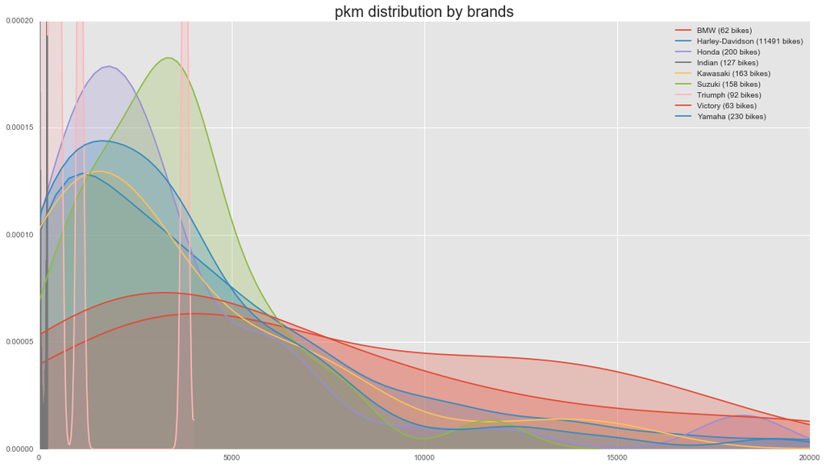

```python
cityP = pd.read_csv("cityP.csv")
cityP = cityP.rename(columns = {"cty2" : "city", "abb" : "state"})

ctyP = []
for cty in cityP.city:
    ctyP.append(cty)

ctyind = []
for cty in bike.city:
    if cty in ctyP: ctyind.append(True)
    else: ctyind.append(False)

bkrain = bike2[ctyind]

bkrain['precipitation'] = cityP.precipitation
bkrain = bkrain.rename(columns = {"state_x" : "state"})
bkrain = bkrain[(bkrain.makesize > 50)]

group = ['make', 'color', 'condition', 'listed', 'model', 'state', 'city']
ind_name = ['makeindex', 'colindex', 'condindex', 'listedindex', 'modindex', 'stateindex', \
            'cityindex']
size_name = ['makesize', 'colsize', 'condsize', 'listedsize', 'modsize', 'statesize', \
             'citysize']

bkrain['pkm'] = (bkrain.precipitation/1000)*(bkrain.km/(2017 - bkrain.year))
bkrain = bkrain.loc[np.logical_not(np.isnan(bkrain.pkm))]



plt.rcParams['figure.figsize'] = 18, 10
mkleg = []
for mk, df in bkrain.groupby('make'):
    mkleg.append("%s (%s bikes)" %(mk, \
                        int(np.unique(bkrain[bkrain.make == mk]['makesize'])[0])))
    sns.kdeplot(df['pkm'], shade = True)
    plt.ylim([0, 2e-4])
    plt.xlim([0, 2e4])
    plt.legend(mkleg)
plt.title('pkm distribution by brands', size = 20)
plt.tick_params(axis=u'both', which=u'both',length=0);
```

Turns out we see a rather similar behavior, although Suzuki's peak is a little ahead of the others', and BMW (Victory to a lesser extent) show a thick strip all the way from 0 (new vehicles) to 15-20,000 pkm.

Although not very significant due to the little amount of data, this seems consistent with the expected behavior of riders, as Suzuki owners are probably more often commuting wuth their vehicle and BMW owners are often every-day and long trips riders.

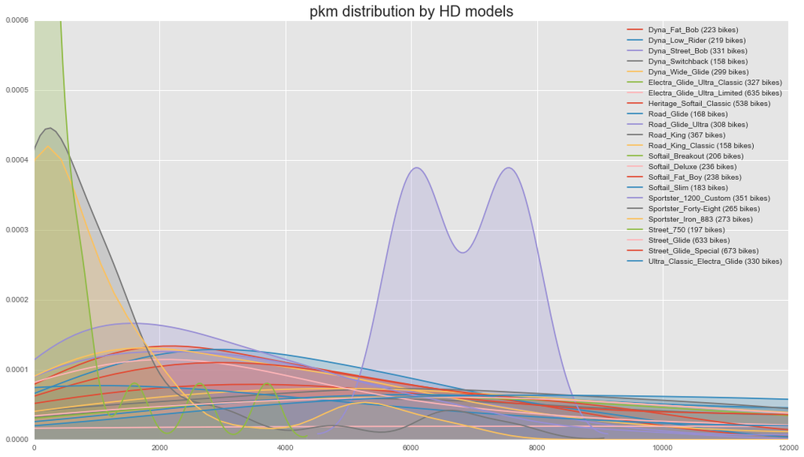

```python
bkHD = bkrain[(bkrain.make == 'Harley-Davidson')]
np.unique(bkHD.model)

bkHD = bkHD.loc[np.logical_not(np.isnan(bkHD.pkm))]
bkHD = bkHD[bkHD.modsize > 150]

modleg = []
for mod, df in bkHD.groupby('model'):
    modleg.append("%s (%s bikes)" %(mod, np.unique(bkHD[bkHD.model == mod]['modsize'])[0]))
    sns.kdeplot(df['pkm'], shade = True)
    plt.xlim([0, 1.2e4])
    plt.ylim([0, 6e-4])
    plt.legend(modleg)
plt.title('pkm distribution by HD models', size = 20)
plt.tick_params(axis=u'both', which=u'both',length=0);
```

Looking only at Harley-Davidsons models for which we have more data, we seem to get a more distinct behavior. For most models there is a thick strip of different pkm, indicating that any kind of behavior is possible. However for some models such as Dyna, Electra Glide and Road King see their peaks at low pkm, while the Road Glide sees a double peak at high pkms. This seems to indicate the first owners are more wary of rainy conditions when the latter would not be so easily dettered from driving in difficult weather conditions.